# Clean the data for Game of Thrones Characters

### Read the dataset from Fusion Tables

```python
import csv
import httplib2
from apiclient.discovery import build
import urllib
import json
import numpy as np
import pandas as pd
import matplotlib as mpl
import matplotlib.pyplot as plt
import seaborn as sns

# API from the project
API_KEY = 'AIzaSyDOHHGMoCwdyC0owPNuiFc8TmOfsa6jkKo'

# Google Fusion table 'got-characters'
TABLE_ID = '1y8W-YaQn3hrI4TZxp67k5INA50eYedJiw02JwgVR'

try:
    fp = open("data.json")
    response = json.load(fp)
except IOError:
    service = build('fusiontables', 'v1', developerKey=API_KEY)
    query = "SELECT * FROM " + TABLE_ID
    response = service.query().sql(sql=query).execute()
    fp = open("data.json", "w+")
    json.dump(response, fp)

# Convert to pandas DataFrame
got_df = pd.DataFrame(response[u'rows'], columns = response[u'columns'])

#Print first 5 rows
got_df.head()
```

|  | Name | Allegiances | Death_Year | Book_of_Death | Death_Chapter | Book_Intro_Chapter | Gender | Nobility | GoT | CoK | SoS | FfC | DwD |
| --- | --- | --- | --- | --- | --- | --- | --- | --- | --- | --- | --- | --- | --- |
| 0 | Addam Marbrand | Lannister | NaN | NaN | NaN | 56 | 1 | 1 | 1 | 1 | 1 | 1 | 0 |
| 1 | Aegon Frey (Jinglebell) | None | 299 | 3 | 51 | 49 | 1 | 1 | 0 | 0 | 1 | 0 | 0 |
| 2 | Aegon Targaryen | House Targaryen | NaN | NaN | NaN | 5 | 1 | 1 | 0 | 0 | 0 | 0 | 1 |
| 3 | Adrack Humble | House Greyjoy | 300 | 5 | 20 | 20 | 1 | 1 | 0 | 0 | 0 | 0 | 1 |
| 4 | Aemon Costayne | Lannister | NaN | NaN | NaN | NaN | 1 | 1 | 0 | 0 | 1 | 0 | 0 |

Now we want to convert all the chapters from book-specific to a single Game of Thrones timeline

```python
max_chapter = [72, 69, 81, 45, 72] #Number of chapters per book
total_chapter = sum(max_chapter) #Total chapters in the series
got_df=got_df.replace('NaN',np.nan) #Replace 'NaN' strings with NaN from Numpy
```

The following function creates a new column in the dataset putting the Death Chapter (or Intro Chapter) across books in the same timeline. For example, if one character dies on episode 6 of the 2nd book; it's real Death Chapter on the GoT timeline is 72+6=78

```python
def chapter_norm(row, column):
  if column == 'Dead':
    if pd.isnull(row.Book_of_Death): #Character is Alive
        row['Death_Chapter_Norm'] = row.Death_Chapter #Copy NaN
        return row
    else:  #Character is Dead
        book = int(row.Book_of_Death)
        chapter = row.Death_Chapter
        if pd.isnull(chapter): #In case the character died but no chapter is listed, assign the last chapter of that book
          chapter=max_chapter[book-1]
        else:
          chapter = int(chapter)
        for i in range(book-1):
          chapter += max_chapter[i]
    row['Death_Chapter_Norm'] = chapter
  elif column == 'Intro':
    if row['GoT']==str(1):
      book = 1
    elif row['CoK']==str(1):
      book = 2
    elif row['SoS']==str(1):
      book = 3
    elif row['FfC']==str(1):
      book = 4
    else:
      book = 5
    chapter = row.Book_Intro_Chapter
    if pd.isnull(chapter): #In case no chapter is listed, assign the first chapter of that book
      chapter=1
    else:
      chapter = int(chapter)
    for i in range(book-1):
      chapter += max_chapter[i]
    row['Intro_Chapter_Norm'] = chapter
  return row
```

There were inconsistencies in the way the Allegiances were represented, as some rows had the prefix 'House ' and some didn't. Because they represent the same house, we eliminate this prefix

```python
def house_norm(row):
    if row.Allegiances.find('House')==0: #0 if its in the string, -1 if its not
      #Contains House in the name
      row['Allegiances']=row.Allegiances.replace('House ','')
    return row
```

We want to calculate how many chapters a character was alive, that is, how many chapters passed in the timeline since it was first introduced and killed.

```python
def chapters_alive(row):
  if pd.isnull(row.Book_of_Death): #Is Alive
     row['ChaptersAlive'] = total_chapter-int(row['Intro_Chapter_Norm'])
  else:
    row['ChaptersAlive'] = int(row['Death_Chapter_Norm'])-int(row['Intro_Chapter_Norm'])
    if row['ChaptersAlive']<0: #If chapters alive is negative, cap it to 0
      row['ChaptersAlive']=0
  return row
```

We want to change the label from Gender to make it more interpretable

```python
def gender_norm(row):
  if row.Gender == '1':
    row['Gender'] = 'Male'
  else:
    row['Gender'] = 'Female'
  return row
```

#### Putting all the functions together in one function

```python
def clean_data(row):
    row = chapter_norm(row,'Dead')
    row = house_norm(row)
    row = chapter_norm(row,'Intro')
    row = chapters_alive(row)
    row = gender_norm(row)
    return row
```

And applying it to the data

```python
got_df_clean = got_df.apply(lambda x: clean_data(x), axis=1)
got_df_clean.head(10)
```

|  | Name | Allegiances | Death_Year | Book_of_Death | Death_Chapter | Book_Intro_Chapter | Gender | Nobility | GoT | CoK | SoS | FfC | DwD | Death_Chapter_Norm | Intro_Chapter_Norm | ChaptersAlive |
| --- | --- | --- | --- | --- | --- | --- | --- | --- | --- | --- | --- | --- | --- | --- | --- | --- |
| 0 | Addam Marbrand | Lannister | NaN | NaN | NaN | 56 | Male | 1 | 1 | 1 | 1 | 1 | 0 | NaN | 56 | 283 |
| 1 | Aegon Frey (Jinglebell) | None | 299 | 3 | 51 | 49 | Male | 1 | 0 | 0 | 1 | 0 | 0 | 192 | 190 | 2 |
| 2 | Aegon Targaryen | Targaryen | NaN | NaN | NaN | 5 | Male | 1 | 0 | 0 | 0 | 0 | 1 | NaN | 272 | 67 |
| 3 | Adrack Humble | Greyjoy | 300 | 5 | 20 | 20 | Male | 1 | 0 | 0 | 0 | 0 | 1 | 287 | 287 | 0 |
| 4 | Aemon Costayne | Lannister | NaN | NaN | NaN | NaN | Male | 1 | 0 | 0 | 1 | 0 | 0 | NaN | 142 | 197 |
| 5 | Aemon Estermont | Baratheon | NaN | NaN | NaN | NaN | Male | 1 | 0 | 1 | 1 | 0 | 0 | NaN | 73 | 266 |
| 6 | Aemon Targaryen (son of Maekar I) | Night's Watch | 300 | 4 | 35 | 21 | Male | 1 | 1 | 0 | 1 | 1 | 0 | 257 | 21 | 236 |
| 7 | Aenys Frey | None | 300 | 5 | NaN | 59 | Female | 1 | 1 | 1 | 1 | 0 | 1 | 339 | 59 | 280 |
| 8 | Aeron Greyjoy | Greyjoy | NaN | NaN | NaN | 11 | Male | 1 | 0 | 1 | 0 | 1 | 0 | NaN | 83 | 256 |
| 9 | Aethan | Night's Watch | NaN | NaN | NaN | 0 | Male | 0 | 0 | 0 | 1 | 0 | 0 | NaN | 141 | 198 |

### Dead characters per house

We want to measure how the deaths in the series are distributed between houses. We start by aggregating the characters based on their allegiance, and sorting them based on the frequency on descending order.

Then, we do the same for only the characters that have died.

```python
dead_characters=got_df_clean[pd.isnull(got_df_clean.Book_of_Death)==False]
char_per_house = got_df_clean.groupby('Allegiances').agg(pd.Series.nunique).sort_values('Name', ascending = False)
char_per_house['Allegiances'] = char_per_house.index
dead_char_per_house = dead_characters.groupby('Allegiances').agg(pd.Series.nunique).sort_values('Name', ascending = False)
dead_char_per_house['Allegiances'] = dead_char_per_house.index
```

And we plot our findings

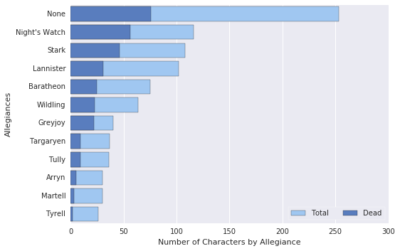

```python
# Initialize the matplotlib figure
f, ax = plt.subplots()

#Plot total characters per house
sns.set_color_codes("pastel")
sns.barplot(x="Name", y="Allegiances", data=char_per_house, label="Total", color="b")

#Plot total dead characters per house
sns.set_color_codes("muted")
sns.barplot(x="Name", y="Allegiances", data=dead_char_per_house, label="Dead", color="b")

# Add a legend and informative axis label
ax.legend(ncol=2, loc="lower right", frameon=True)
ax.set(xlabel="Number of Characters by Allegiance")
#sns.despine(left=True, bottom=True)
```

### Chapters Alive

We want to see how many chapters characters live on the series and split them by Allegiance to see which houses are more fortunate than others and live longer.

We start by aggregating based on the house, and sorting the data by their median

```python
chapter_order = got_df_clean.groupby('Allegiances').agg(pd.Series.median).sort_values('ChaptersAlive', ascending = False)['ChaptersAlive'].index
```

Then we plot the boxplot along with a stripplot of the data to show the data points as well.

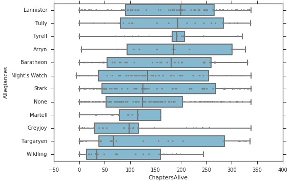

```python
sns.set(style="ticks", palette="muted", color_codes=True)
got_df_clean['ChaptersAlive']=pd.to_numeric(got_df_clean['ChaptersAlive'])
ax = sns.boxplot(x="ChaptersAlive", y="Allegiances", data=got_df_clean, whis=np.inf, color="c", order = chapter_order)
sns.stripplot(x="ChaptersAlive", y="Allegiances", data=got_df_clean, jitter=False, size=3, color=".5", linewidth=0, order = chapter_order)
```

### Gender Analysis

We want to see if men are more likely than women to die on the show.

```python
gender_count = got_df_clean['Gender'].value_counts()
gender_count
```

```
Male      760
Female    157
Name: Gender, dtype: int64
```

The number of deaths per gender is

```python
dead_characters_gender=got_df_clean[pd.isnull(got_df_clean.Book_of_Death)==False].Gender.value_counts()
dead_characters_gender
```

```
Male      271
Female     36
Name: Gender, dtype: int64
```

```python
char_per_gender = got_df_clean.groupby('Gender').agg(pd.Series.nunique).sort_values('Name', ascending = False)
char_per_gender['Gender'] = char_per_gender.index
dead_char_per_gender = dead_characters.groupby('Gender').agg(pd.Series.nunique).sort_values('Name', ascending = False)
dead_char_per_gender['Gender'] = dead_char_per_gender.index
dead_char_per_gender['death_prob']=dead_char_per_gender['Name']/char_per_gender['Name']
```

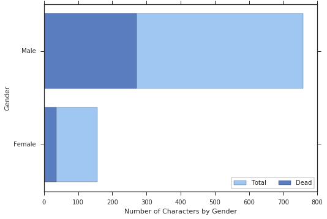

```python
 # Initialize the matplotlib figure
f, ax = plt.subplots()

#Plot total characters per house
sns.set_color_codes("pastel")
sns.barplot(x="Name", y="Gender", data=char_per_gender, label="Total", color="b")

#Plot total dead characters per house
sns.set_color_codes("muted")
sns.barplot(x="Name", y="Gender", data=dead_char_per_gender, label="Dead", color="b")

# Add a legend and informative axis label
ax.legend(ncol=2, loc="lower right", frameon=True)
ax.set(xlabel="Number of Characters by Gender")
#sns.despine(left=True, bottom=True)
```

We calculate the death probability

```python
dead_char_per_gender
```

| Gender | Name | Allegiances | Death_Year | Book_of_Death | Death_Chapter | Book_Intro_Chapter | Nobility | GoT | CoK | SoS | FfC | DwD | Death_Chapter_Norm | Intro_Chapter_Norm | ChaptersAlive | Gender | death_prob |
| --- | --- | --- | --- | --- | --- | --- | --- | --- | --- | --- | --- | --- | --- | --- | --- | --- | --- |
| Male | 271 | 12 | 4 | 5 | 67 | 66 | 2 | 2 | 2 | 2 | 2 | 2 | 135 | 134 | 111 | Male | 0.357049 |
| Female | 36 | 8 | 3 | 5 | 23 | 20 | 2 | 2 | 2 | 2 | 2 | 2 | 26 | 25 | 22 | Female | 0.229299 |

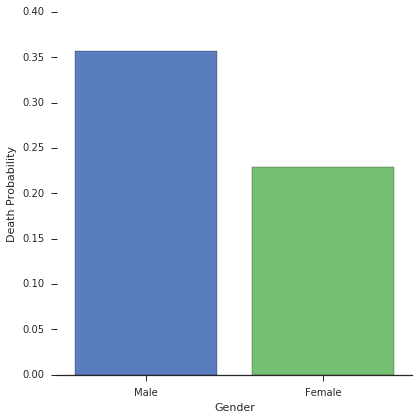

```python
g = sns.factorplot(x="Gender", y="death_prob", data=dead_char_per_gender, size=6, kind="bar", palette="muted")
g.despine(left=True)
g.set_ylabels("Death Probability")
```

```python
got_df_clean.loc[pd.isnull(got_df_clean.Book_of_Death)==False,'isAlive']=0
got_df_clean.loc[pd.isnull(got_df_clean.Book_of_Death)==True,'isAlive']=1
```

```python
survival = got_df_clean['Gender'=='Female'].groupby(['Allegiances']).agg(pd.Series.mean).sort_values('isAlive', ascending = False)
survival['Allegiances'] = survival.index
```

```python
#Group by gender and allegiance, and sort in descending order

female_data = got_df_clean[got_df_clean['Gender']=='Female'].groupby(['Allegiances']).agg(pd.Series.mean).sort_values('isAlive', ascending = False)
female_data['Allegiances']=female_data.index
male_data = got_df_clean[got_df_clean['Gender']=='Male'].groupby(['Allegiances']).agg(pd.Series.mean).sort_values('isAlive', ascending = False)
male_data['Allegiances']=male_data.index
```

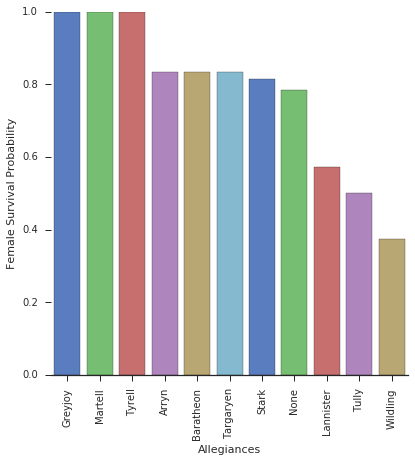

```python
g = sns.factorplot(x="Allegiances", y="isAlive", data=female_data, size=6, kind="bar", palette="muted")
g.despine(left=True)
g.set_ylabels("Female Survival Probability")
g.set_xticklabels(rotation=90)
```

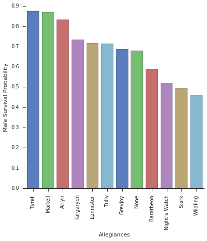

```python
g = sns.factorplot(x="Allegiances", y="isAlive", data=male_data, size=6, kind="bar", palette="muted")
g.despine(left=True)
g.set_ylabels("Male Survival Probability")
g.set_xticklabels(rotation=90)
```

```python
got_df_clean['ChaptersAlive'].median()
```

```
126.0
```